# Publishing Tables and Figures from didhelpers

## Overview

This vignette demonstrates how to turn **didhelpers** diagnostic output into publication-quality tables and figures suitable for academic papers, slide decks, and reports.

We cover four output paths:

1. **gt / kableExtra tables** via `as_table()`
2. **broom-style tidy output** via `tidy()`, `glance()`, `augment()`
3. **Regression tables** via `modelsummary` (LaTeX, Word, HTML)
4. **Customized ggplot2 figures** for publication

## Setup

```r
library(didhelpers)
library(ggplot2)
data("staggered_data")

# Run diagnostics
pt <- test_pretrends(staggered_data, unit, time, outcome, treat, n_lags = 3)
```

```
#> Wald test, H0: joint nullity of lead_3 and lead_2
#>  stat = 0.232853, p-value = 0.792378, on 2 and 400 DoF, VCOV: IID.
```

```r
bs <- bacon_weight_summary(staggered_data, unit, time, outcome, treat)
```

## 1. Publication Tables with gt

The `as_table()` function produces formatted tables for direct inclusion in RMarkdown and Quarto documents.

```r
as_table(pt, format = "gt")
```

Event-Study Coefficients

| Term | Estimate | Std. Error | t value | Pr(>\|t\|) | CI Low | CI High |  |
| --- | --- | --- | --- | --- | --- | --- | --- |
| lead_3 | −0.002 | 0.134 | −0.015 | 0.9881 | −0.264 | 0.260 |  |
| lead_2 | −0.092 | 0.174 | −0.528 | 0.5979 | −0.432 | 0.249 |  |
| lag_0 | 1.928 | 0.172 | 11.212 | 0.0000 | 1.591 | 2.265 | *** |
| lag_1 | 1.946 | 0.175 | 11.111 | 0.0000 | 1.602 | 2.289 | *** |
| lag_2 | 1.844 | 0.154 | 11.940 | 0.0000 | 1.541 | 2.147 | *** |
| lag_3 | 1.949 | 0.146 | 13.390 | 0.0000 | 1.664 | 2.234 | *** |

Joint F-test of pre-treatment leads: F = 0.233, p = 0.7924. Signif. codes: 0 '***' 0.001 '**' 0.01 '*' 0.05 '.' 0.1

```r
as_table(bs, format = "gt")
```

Goodman-Bacon Decomposition Summary

| Comparison Type | N | Weight | Wtd. Avg. Estimate |
| --- | --- | --- | --- |
| Earlier vs Later Treated | 3 | 0.229 | 2.003 |
| Later vs Earlier Treated | 3 | 0.198 | 2.021 |
| Treated vs Untreated | 3 | 0.573 | 1.888 |

Overall TWFE estimate: 1.9405. Based on 9 2x2 comparisons.

For kableExtra output (better for LaTeX/PDF documents), use `format = "kable"`:

```r
as_table(pt, format = "kable")
```

Event-Study Coefficients

| term | estimate | std.error | statistic | p.value | conf.low | conf.high | stars |
| --- | --- | --- | --- | --- | --- | --- | --- |
| lead_3 | -0.002 | 0.134 | -0.015 | 0.988 | -0.264 | 0.260 |  |
| lead_2 | -0.092 | 0.174 | -0.528 | 0.598 | -0.432 | 0.249 |  |
| lag_0 | 1.928 | 0.172 | 11.212 | 0.000 | 1.591 | 2.265 | *** |
| lag_1 | 1.946 | 0.175 | 11.111 | 0.000 | 1.602 | 2.289 | *** |
| lag_2 | 1.844 | 0.154 | 11.940 | 0.000 | 1.541 | 2.147 | *** |
| lag_3 | 1.949 | 0.146 | 13.390 | 0.000 | 1.664 | 2.234 | *** |

You can control the number of decimal places with the `digits` argument:

```r
as_table(pt, format = "gt", digits = 4)
```

Event-Study Coefficients

| Term | Estimate | Std. Error | t value | Pr(>\|t\|) | CI Low | CI High |  |
| --- | --- | --- | --- | --- | --- | --- | --- |
| lead_3 | −0.0020 | 0.1335 | −0.0149 | 0.9881 | −0.2637 | 0.2597 |  |
| lead_2 | −0.0917 | 0.1737 | −0.5278 | 0.5979 | −0.4322 | 0.2488 |  |
| lag_0 | 1.9283 | 0.1720 | 11.2118 | 0.0000 | 1.5912 | 2.2654 | *** |
| lag_1 | 1.9457 | 0.1751 | 11.1115 | 0.0000 | 1.6025 | 2.2889 | *** |
| lag_2 | 1.8439 | 0.1544 | 11.9405 | 0.0000 | 1.5412 | 2.1466 | *** |
| lag_3 | 1.9489 | 0.1456 | 13.3897 | 0.0000 | 1.6636 | 2.2342 | *** |

Joint F-test of pre-treatment leads: F = 0.233, p = 0.7924. Signif. codes: 0 '***' 0.001 '**' 0.01 '*' 0.05 '.' 0.1

## 2. Broom Integration

The `tidy()`, `glance()`, and `augment()` methods make didhelpers objects work seamlessly in tidyverse workflows and with **modelsummary**.

### Tidy coefficients

```r
tidy(pt)
```

```
#> # A tibble: 6 × 7
#>   term   estimate std.error statistic  p.value conf.low conf.high
#>   <chr>     <dbl>     <dbl>     <dbl>    <dbl>    <dbl>     <dbl>
#> 1 lead_3 -0.00199     0.134   -0.0149 9.88e- 1   -0.264     0.260
#> 2 lead_2 -0.0917      0.174   -0.528  5.98e- 1   -0.432     0.249
#> 3 lag_0   1.93        0.172   11.2    1.48e-25    1.59      2.27
#> 4 lag_1   1.95        0.175   11.1    3.51e-25    1.60      2.29
#> 5 lag_2   1.84        0.154   11.9    2.56e-28    1.54      2.15
#> 6 lag_3   1.95        0.146   13.4    4.86e-34    1.66      2.23
```

You can control confidence intervals:

```r
# Without confidence intervals
tidy(pt, conf.int = FALSE)
```

```
#> # A tibble: 6 × 5
#>   term   estimate std.error statistic  p.value
#>   <chr>     <dbl>     <dbl>     <dbl>    <dbl>
#> 1 lead_3 -0.00199     0.134   -0.0149 9.88e- 1
#> 2 lead_2 -0.0917      0.174   -0.528  5.98e- 1
#> 3 lag_0   1.93        0.172   11.2    1.48e-25
#> 4 lag_1   1.95        0.175   11.1    3.51e-25
#> 5 lag_2   1.84        0.154   11.9    2.56e-28
#> 6 lag_3   1.95        0.146   13.4    4.86e-34
```

```r
# With 90% confidence intervals
tidy(pt, conf.int = TRUE, conf.level = 0.90)
```

```
#> # A tibble: 6 × 7
#>   term   estimate std.error statistic  p.value conf.low conf.high
#>   <chr>     <dbl>     <dbl>     <dbl>    <dbl>    <dbl>     <dbl>
#> 1 lead_3 -0.00199     0.134   -0.0149 9.88e- 1   -0.222     0.218
#> 2 lead_2 -0.0917      0.174   -0.528  5.98e- 1   -0.377     0.194
#> 3 lag_0   1.93        0.172   11.2    1.48e-25    1.65      2.21
#> 4 lag_1   1.95        0.175   11.1    3.51e-25    1.66      2.23
#> 5 lag_2   1.84        0.154   11.9    2.56e-28    1.59      2.10
#> 6 lag_3   1.95        0.146   13.4    4.86e-34    1.71      2.19
```

### Model-level statistics

```r
glance(pt)
```

```
#> # A tibble: 1 × 7
#>    nobs r.squared adj.r.squared f_statistic f_p_value n_leads n_lags
#>   <int>     <dbl>         <dbl>       <dbl>     <dbl>   <int>  <int>
#> 1   450     0.947         0.940       0.233     0.792       2      4
```

### Fitted values and residuals

```r
head(augment(pt))
```

```
#> # A tibble: 6 × 2
#>   .fitted .resid
#>     <dbl>  <dbl>
#> 1    4.12 -0.289
#> 2    1.16  0.444
#> 3    1.33 -0.505
#> 4    1.57 -0.337
#> 5    1.66  0.244
#> 6    1.86 -0.279
```

### Bacon decomposition

```r
# Per-type summary
tidy(bs, type = "summary")
```

```
#> # A tibble: 3 × 4
#>   type                     n_comparisons total_weight weighted_avg_estimate
#>   <chr>                            <int>        <dbl>                 <dbl>
#> 1 Earlier vs Later Treated             3        0.229                  2.00
#> 2 Later vs Earlier Treated             3        0.198                  2.02
#> 3 Treated vs Untreated                 3        0.573                  1.89
```

```r
# All 2×2 comparisons
tidy(bs, type = "two_by_twos")
```

```
#> # A tibble: 9 × 5
#>   treated untreated estimate weight type
#>     <dbl>     <dbl>    <dbl>  <dbl> <chr>
#> 1       9         6     1.91 0.0866 Later vs Earlier Treated
#> 2      12         6     2.25 0.0742 Later vs Earlier Treated
#> 3       6         9     2.07 0.0619 Earlier vs Later Treated
#> 4      12         9     1.82 0.0371 Later vs Earlier Treated
#> 5       6        12     2.15 0.0928 Earlier vs Later Treated
#> 6       9        12     1.76 0.0742 Earlier vs Later Treated
#> 7       6     99999     1.94 0.206  Treated vs Untreated
#> 8       9     99999     1.84 0.231  Treated vs Untreated
#> 9      12     99999     1.89 0.136  Treated vs Untreated
```

```r
# Decomposition-level stats
glance(bs)
```

```
#> # A tibble: 1 × 4
#>   twfe_estimate n_comparisons n_types max_weight
#>           <dbl>         <int>   <int>      <dbl>
#> 1          1.94             9       3      0.231
```

## 3. LaTeX and Word Export via modelsummary

With broom methods in place, **modelsummary** works automatically. This is the recommended path for regression tables in academic papers.

```r
# Interactive HTML/gt display
export_pretrends_table(pt)
```

|  | Event-Study |
| --- | --- |
| lead_3 | -0.002 |
|  | (0.134) |
| lead_2 | -0.092 |
|  | (0.174) |
| lag_0 | 1.928 |
|  | (0.172) |
| lag_1 | 1.946 |
|  | (0.175) |
| lag_2 | 1.844 |
|  | (0.154) |
| lag_3 | 1.949 |
|  | (0.146) |
| Num.Obs. | 450 |
| R2 | 0.947 |
| R2 Adj. | 0.940 |
| f_statistic | 0 |
| f_p_value | 1 |

```r
# LaTeX output (paste into your .tex file)
export_pretrends_table(pt, output = "latex")
```

To export directly to a Word document:

```r
# Save to .docx (requires flextable)
export_pretrends_table(pt, output = "my_table.docx")
```

You can also call **modelsummary** directly for more control:

```r
library(modelsummary)
modelsummary(
  list("Event-Study" = pt),
  stars = c("*" = 0.1, "**" = 0.05, "***" = 0.01)
)
```

### Why modelsummary?

| Package | S3 extensible | LaTeX | Word | Maintained |
| --- | --- | --- | --- | --- |
| modelsummary | Yes | Yes | Yes | Yes |
| stargazer | No | Yes | No | No (2022) |
| huxtable | Partial | Yes | Yes | Yes |

**modelsummary** is the best fit because it uses `tidy()` and `glance()` automatically, supports all output formats, and integrates with gt and kableExtra.

## 4. Publication-Ready Figures

All plot methods return ggplot2 objects that can be further customized with standard ggplot2 layers.

### Event-study plot

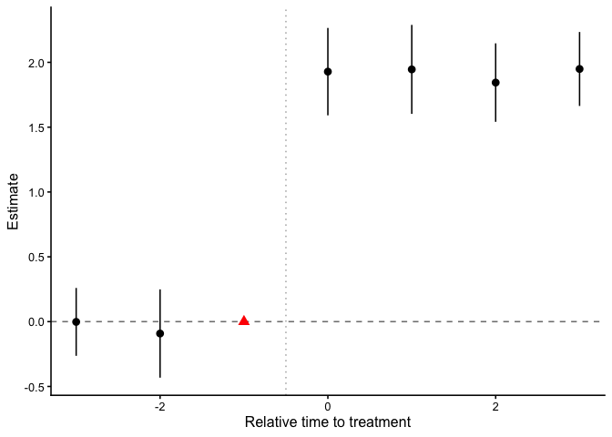

```r
autoplot(pt) +
  theme_classic(base_size = 12) +
  labs(title = NULL, caption = NULL) +
  theme(legend.position = "none")
```

### Adjusting confidence level

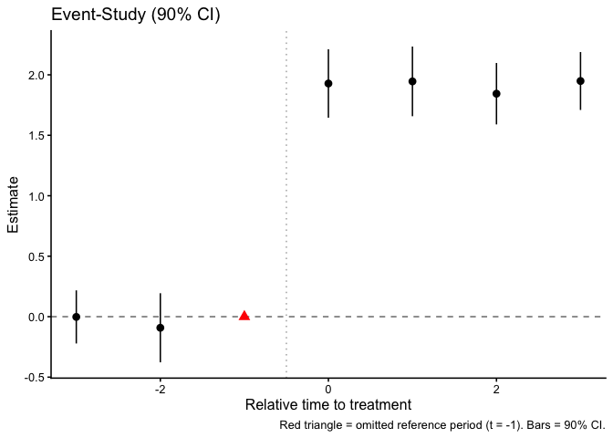

```r
autoplot(pt, conf.level = 0.90) +
  theme_classic(base_size = 12) +
  labs(title = "Event-Study (90% CI)")
```

### Bacon decomposition plot

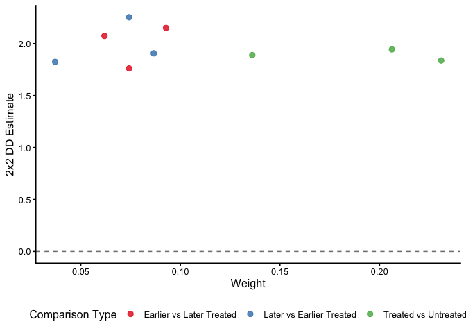

```r
autoplot(bs) +
  theme_classic(base_size = 12) +
  labs(title = NULL) +
  theme(legend.position = "bottom")
```

### Composite report figure

```r
report <- did_diagnostics_report(staggered_data, unit, time, outcome, treat)
```

```
#> Wald test, H0: joint nullity of lead_3 and lead_2
#>  stat = 0.232853, p-value = 0.792378, on 2 and 400 DoF, VCOV: IID.
```

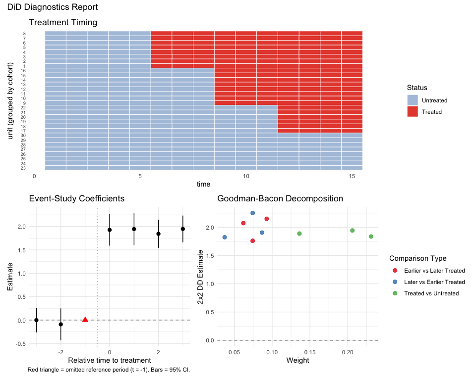

```r
plot(report)
```

## Summary

| Task | Function / Method |
| --- | --- |
| Console summary | `print()`, `summary()` |
| Tidy coefficient table | `tidy(pt)`, `tidy(pt, conf.level = 0.90)` |
| Model-level stats | `glance(pt)` |
| Fitted values / residuals | `augment(pt)` |
| gt / kableExtra table | `as_table(pt)`, `as_table(bs)` |
| LaTeX regression table | `export_pretrends_table(pt, output = "latex")` |
| Word regression table | `export_pretrends_table(pt, output = "file.docx")` |
| modelsummary (direct) | `modelsummary::modelsummary(list(pt))` |
| Publication ggplot2 figures | `autoplot(pt) + theme_classic()` |
| Composite diagnostics plot | `plot(report)` (requires patchwork) |